# COVID-19 Project

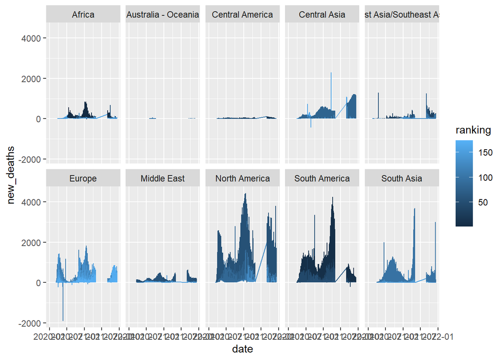

```r
ggplot(covid_gini,mapping = aes(x=date,y=new_deaths))+geom_line(mapping = aes(color=ranking))+
  facet_wrap(~region, nrow = 2)
```

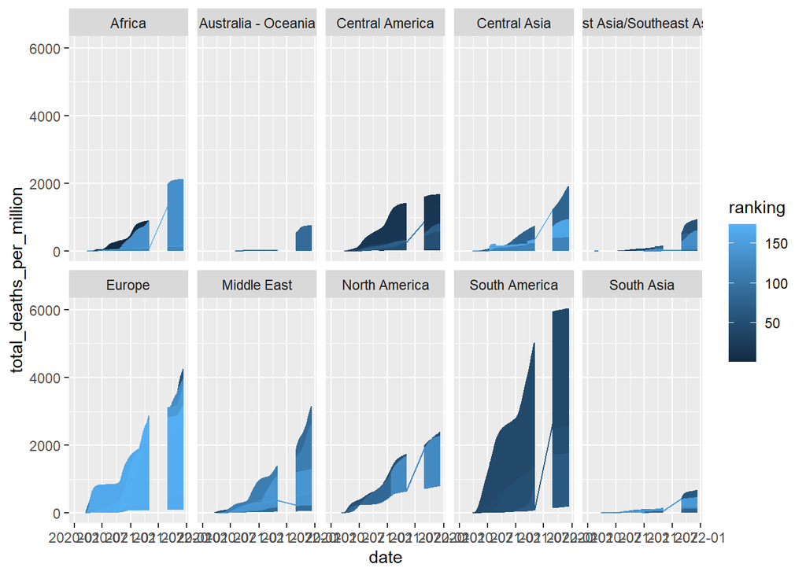

```r
ggplot(covid_gini,mapping = aes(x=date,y=total_deaths_per_million))+geom_line(mapping = aes(color=ranking))+
  facet_wrap(~region, nrow = 2)
```

From the graphs above, Africa, Middle East, South America, and East Asia/Southeast Asia show the impact from gini coefficient on deaths more clear. The reason might be these regions have relatively higher Gini coefficient than other regions. Europe, North America and South Asia have low Gini coefficient with a relatively unclear pattern on the relationship between Gini coefficient and deaths. However, comparing across regions, with lower Gini coefficient, Europe would have a lower peak than South America which have high Gini coefficient. To conclude, Gini coefficient seems have obvious impact on COVID-19 deaths number. However, in some regions, the patterns are not clear of the deaths are relatively small such as East Asia/Southeast Asia. It might be explained by other factors. For example, the political concentrated might affect the control of the COVID-19 that might help to decrease the deaths.

**COVID-19 and GDP**

GDP is a main part to represents the performance of a country. It counts the total final goods and services produced within a country during a year. That means a higher GDP illustrates a countries high ability in productivity. In this way, when facing a natural crisis, it would be more likely to actively deal with the problem. Under COVID-19, we assume a high GDP country would have ability to handle and afford the cases in closing the work place that might decrease the production of a country. The period is randomly select that are before May 01 and after Sept 01.

```r
library(dplyr)
library(magrittr)
covid_reponse<-covid_response%>%mutate(Date=as.Date(Date,format ="%Y-%m-%d"))
covid_gdp<-left_join(gdppp, covid_response, by = c("name" ="CountryName"))%>%filter(Date<=ymd("2021-05-01")|Date>=ymd("2021-09-01"))#%>%mutate(value=as.integer(as.character(value)))
```

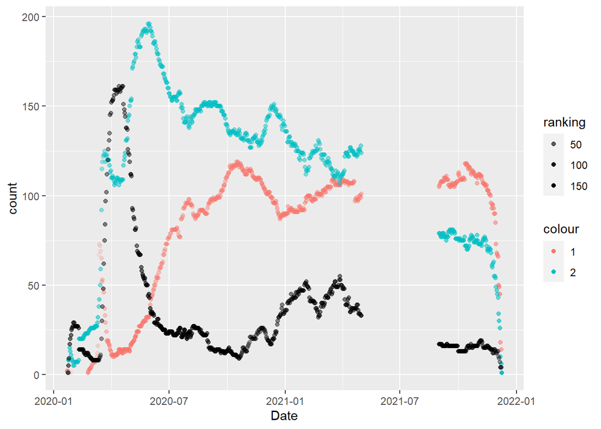

```r
covid_gdp_work_1<-covid_gdp%>%filter(`C2_Workplace closing`=="1"|`C2_Workplace closing`=="1.00")%>%group_by(Date)%>%select(name,Date,ranking)%>%summarise(count=n(),ranking=mean(ranking))
covid_gdp_work_2<-covid_gdp%>%filter(`C2_Workplace closing`=="2"|`C2_Workplace closing`=="2.00")%>%group_by(Date)%>%select(name,Date,ranking)%>%summarise(count=n(),ranking=mean(ranking))
covid_gdp_work_3<-covid_gdp%>%filter(`C2_Workplace closing`=="3"|`C2_Workplace closing`=="3.00")%>%group_by(Date)%>%select(name,Date,ranking)%>%summarise(count=n(),ranking=mean(ranking))

ggplot(covid_gdp_work_1)+geom_point(covid_gdp_work_1,mapping=aes(x=Date,y=count,color="1",alpha=ranking))+geom_point(covid_gdp_work_2,mapping=aes(x=Date,y=count,color="2",alpha=ranking))+geom_point(covid_gdp_work_3,mapping=aes(x=Date,y=count,alpha=ranking))
```

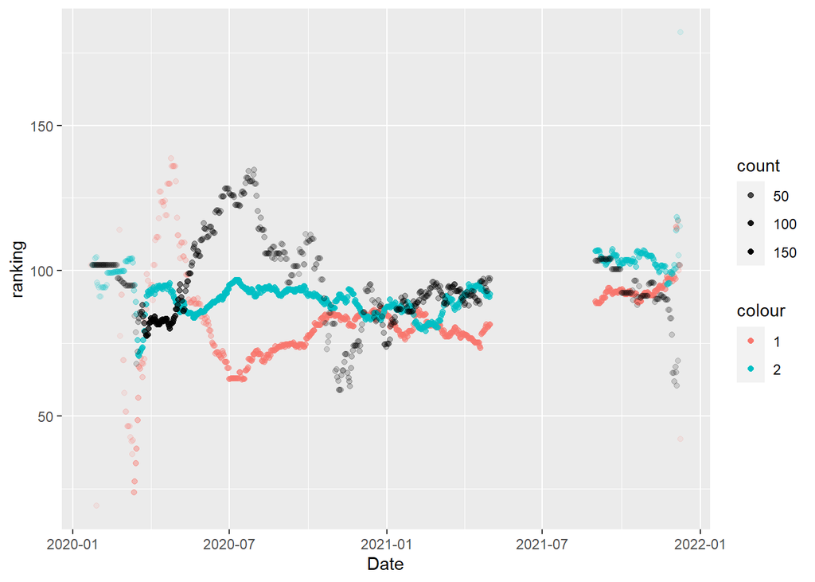

```r
ggplot(covid_gdp_work_1)+geom_point(mapping = aes(x=Date,y=ranking,color="1",alpha=count))+geom_point(covid_gdp_work_2,mapping = aes(x=Date,y=ranking,color="2",alpha=count))+geom_point(covid_gdp_work_3,mapping = aes(x=Date,y=ranking,alpha=count))
```

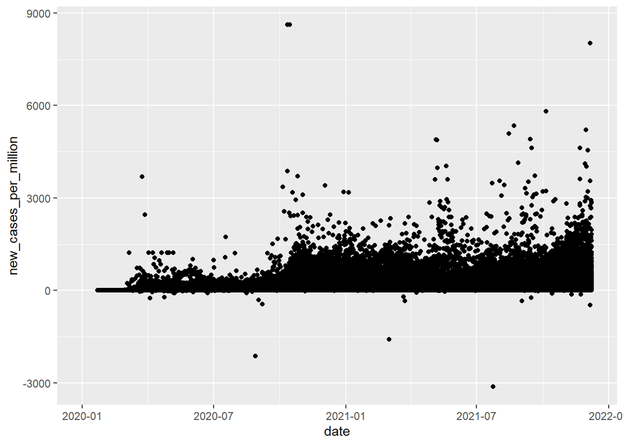

```r
ggplot(covid_gdp_work_1)+geom_point(covid_cases,mapping=aes(x=date,y=new_cases_per_million))
```

# Cagri Isilak Report

*Return to Introduction*

## Hypothesis: Covid cases went down after vaccines came out/during lockdown

Vaccines began to come out in Canada around May 2020. Covid lockdowns began in March 2020.

During lockdown, there is less people interacting and much more social distancing, meaning the virus will have a much harder time spreading. The dataset below is the covid 19 case-count per day for 2020 (all countries). I will be basing my analysis of the lockdown and vaccination dates of Canada, which were not too different from the rest of the world.

```r
# retrieved @ https://data.europa.eu/data/datasets/covid-19-coronavirus-data-daily-up-to-14-december-2020?locale=en
Daily_Cases <- read_csv("DailyCases.csv")

Daily_Cases %>%
  head()
```

```
## # A tibble: 6 x 12
##   dateRep   day month  year cases deaths countriesAndTer~ geoId countryterritor~
##   <chr>   <dbl> <dbl> <dbl> <dbl>  <dbl> <chr>            <chr> <chr>
## 1 14/12/~    14    12  2020   746      6 Afghanistan      AF    AFG
## 2 13/12/~    13    12  2020   298      9 Afghanistan      AF    AFG
## 3 12/12/~    12    12  2020   113     11 Afghanistan      AF    AFG
## 4 11/12/~    11    12  2020    63     10 Afghanistan      AF    AFG
## 5 10/12/~    10    12  2020   202     16 Afghanistan      AF    AFG
## 6 09/12/~     9    12  2020   135     13 Afghanistan      AF    AFG
## # ... with 3 more variables: popData2019 <dbl>, continentExp <chr>,
## #   Cumulative_number_for_14_days_of_COVID-19_cases_per_100000 <dbl>
```

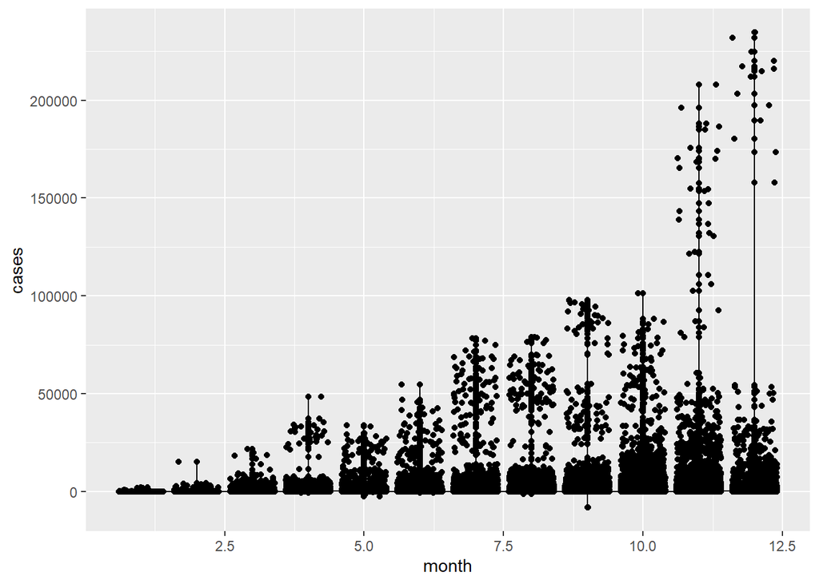

```r
ggplot(Daily_Cases, aes(x=month,y=cases))+
  geom_line()+
  geom_point()+
  geom_jitter()
```

In the graph above, we can see that the increase of cases slowed down a bit in March when lockdowns started, and also dipped slightly down in May which is when vaccines began coming out. From there on we can see that although cases continued increasing in most countries, more and more countries had lower cases, and we can see this the most clearly in December. In addition, I believe the branching off of two visible sections, countries with ever increasing covid cases and countries with decreasing covid cases, can be explained since by then society was getting more used to life in lockdown and more people were getting vacccinated, however at the same time many people had enough of the lockdown and wanted restrictions to lift, which led to many large scale protests that were broadcasted to television around that time. I believe that these protests along with the rising number of people who believe in conspiracy theories combined with those who are not yet vaccinated and anti-vaxxers (people who refuse to be vaccinated because they do not trust the vaccine or for other reasons) are the reason why Covid cases are still increasing. Another very big reason for a continuous increase of Covid cases is the introduction of mutations that can nullify the protection of some vaccines. Mutations, such as a Delta Variant are most likely why there is a large spike in cases in many countries in December, as that is when the Delta variant was first identified, and it had probably begun spreading a lot more by then.